# DATA 606 Final Project

Yohannes Deboch

#### Introduction

For this project, the main concentration will be identifying the contributing factors that actively influence the car consumption, that is the miles consumed per gallon on an individual vehicle. The analysis is mainly influenced by the fact that different vehicles are priced based on factors such as the mileage per gallon statistic, and on an actual real world issue as the mileage per gallon factor greatly influences the resale value of each model. For instance, a vehicle with a high mileage per gallon may seem to be of excessive consumption and that has a little fuel economy, and thus unaffordable to many.

The main goal of this project therefore is to find out whether there exists any relationship between the mileage per gallon variable and other factors such as the weight, horsepower, acceleration which actively influence the consumption level of a vehicle.

### Data Preparation

Our data consideration was from the UCL library, https://archive.ics.uci.edu/ml/datasets/Auto+MPG.

```r
cars <- read.table("https://archive.ics.uci.edu/ml/machine-learning-databases/auto-mpg/auto-mpg.data", header = FALSE)
colnames(cars) <- c("mpg","cylinders","displacement","horsepower","weight","acceleration","model year","origin","car name")
```

### Objective of the Research

The main objective of the research was to determine whether there were any influential factors that actively altered the record of car mileage per gallon in the active dataset. The research problem tried to answer the question on whether it would be possible to make predictions on car mileage per gallon using other underlying factors, which were all in the selected dataset

### Cases

```r
nrow(cars)
```

```
## [1] 398
```

### Data collection

The dataset in consideration is the Auto Mpg dataset, which was obtained from the UCI machine learning repository website. https://archive.ics.uci.edu/ml/datasets/Auto+MPG.

### Type of study

Since the study involves numeric variables, it will be an observational study, and will further be complemented by a case analysis using regression analysis with the mileage per gallon column being our dependent variable.

### Data Source

Data link https://archive.ics.uci.edu/ml/datasets/Auto+MPG

### Response Variable

Mile per gallon (mpg) is the dependent variable. It’s continuous.

### Independent Variable

The independent variables in the analysis are all the other columns except the mileage per gallon one, as seen below.

```r
colnames(cars)[2:8]
```

```
## [1] "cylinders"    "displacement" "horsepower"   "weight"
## [5] "acceleration" "model year"   "origin"
```

### Relevant summary statistics

In its raw form, the dataset structure is in its required state, with all the variables being either in their numeric form, while the horspower and car name being factor variables.

```r
str(cars)
```

```
## 'data.frame':    398 obs. of  9 variables:
##  $ mpg         : num  18 15 18 16 17 15 14 14 14 15 ...
##  $ cylinders   : int  8 8 8 8 8 8 8 8 8 8 ...
##  $ displacement: num  307 350 318 304 302 429 454 440 455 390 ...
##  $ horsepower  : Factor w/ 94 levels "?","100.0","102.0",..: 17 35 29 29 24 42 47 46 48 40 ...
##  $ weight      : num  3504 3693 3436 3433 3449 ...
##  $ acceleration: num  12 11.5 11 12 10.5 10 9 8.5 10 8.5 ...
##  $ model year  : int  70 70 70 70 70 70 70 70 70 70 ...
##  $ origin      : int  1 1 1 1 1 1 1 1 1 1 ...
##  $ car name    : Factor w/ 305 levels "amc ambassador brougham",..: 50 37 232 15 162 142 55 224 242 2 ...
```

observing the First and last few rows of the data

```r
head(cars)
```

|  | mpg | cylinders | displacement | horsepower | weight | acceleration | model year | origin | car name |
| --- | --- | --- | --- | --- | --- | --- | --- | --- | --- |
| 1 | 18 | 8 | 307 | 130.0 | 3504 | 12.0 | 70 | 1 | chevrolet chevelle malibu |
| 2 | 15 | 8 | 350 | 165.0 | 3693 | 11.5 | 70 | 1 | buick skylark 320 |
| 3 | 18 | 8 | 318 | 150.0 | 3436 | 11.0 | 70 | 1 | plymouth satellite |
| 4 | 16 | 8 | 304 | 150.0 | 3433 | 12.0 | 70 | 1 | amc rebel sst |
| 5 | 17 | 8 | 302 | 140.0 | 3449 | 10.5 | 70 | 1 | ford torino |
| 6 | 15 | 8 | 429 | 198.0 | 4341 | 10.0 | 70 | 1 | ford galaxie 500 |

```r
tail(cars)
```

|  | mpg | cylinders | displacement | horsepower | weight | acceleration | model year | origin | car name |
| --- | --- | --- | --- | --- | --- | --- | --- | --- | --- |
| 393 | 27 | 4 | 151 | 90.00 | 2950 | 17.3 | 82 | 1 | chevrolet camaro |
| 394 | 27 | 4 | 140 | 86.00 | 2790 | 15.6 | 82 | 1 | ford mustang gl |
| 395 | 44 | 4 | 97 | 52.00 | 2130 | 24.6 | 82 | 2 | vw pickup |
| 396 | 32 | 4 | 135 | 84.00 | 2295 | 11.6 | 82 | 1 | dodge rampage |
| 397 | 28 | 4 | 120 | 79.00 | 2625 | 18.6 | 82 | 1 | ford ranger |
| 398 | 31 | 4 | 119 | 82.00 | 2720 | 19.4 | 82 | 1 | chevy s-10 |

```r
summary(cars)
```

```
##       mpg          cylinders      displacement     horsepower
##  Min.   : 9.00   Min.   :3.000   Min.   : 68.0   150.0  : 22
##  1st Qu.:17.50   1st Qu.:4.000   1st Qu.:104.2   90.00  : 20
##  Median :23.00   Median :4.000   Median :148.5   88.00  : 19
##  Mean   :23.51   Mean   :5.455   Mean   :193.4   110.0  : 18
##  3rd Qu.:29.00   3rd Qu.:8.000   3rd Qu.:262.0   100.0  : 17
##  Max.   :46.60   Max.   :8.000   Max.   :455.0   75.00  : 14
##                                                  (Other):288
##      weight      acceleration     model year        origin
##  Min.   :1613   Min.   : 8.00   Min.   :70.00   Min.   :1.000
##  1st Qu.:2224   1st Qu.:13.82   1st Qu.:73.00   1st Qu.:1.000
##  Median :2804   Median :15.50   Median :76.00   Median :1.000
##  Mean   :2970   Mean   :15.57   Mean   :76.01   Mean   :1.573
##  3rd Qu.:3608   3rd Qu.:17.18   3rd Qu.:79.00   3rd Qu.:2.000
##  Max.   :5140   Max.   :24.80   Max.   :82.00   Max.   :3.000
##
##            car name
##  ford pinto    :  6
##  amc matador   :  5
##  ford maverick :  5
##  toyota corolla:  5
##  amc gremlin   :  4
##  amc hornet    :  4
##  (Other)       :369
```

From the summary statistics, we can observe that the maximum weight of the cars in consideration is 5140, while the minimum is 1613. The mean and median, on the other hand, are relatively close to each other, suggesting that the distribution of the data may be close to a normal distribution

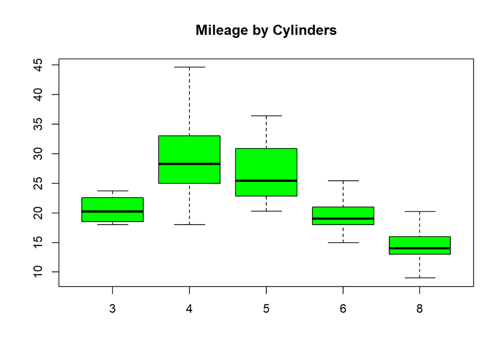

```r
boxplot(cars$mpg~cars$cylinders,main = "Mileage by Cylinders", outline=F, col="green")
```

From the boxplot above, it is evident that car mileage per gallon is high on cars with 4 cylinders, and low on cars with 8 cylinders. Similarly, car mileage per gallon differs with region, as seen on the boxplot below, with Origin 3 posing the cars with the highest level of miles per gallon.

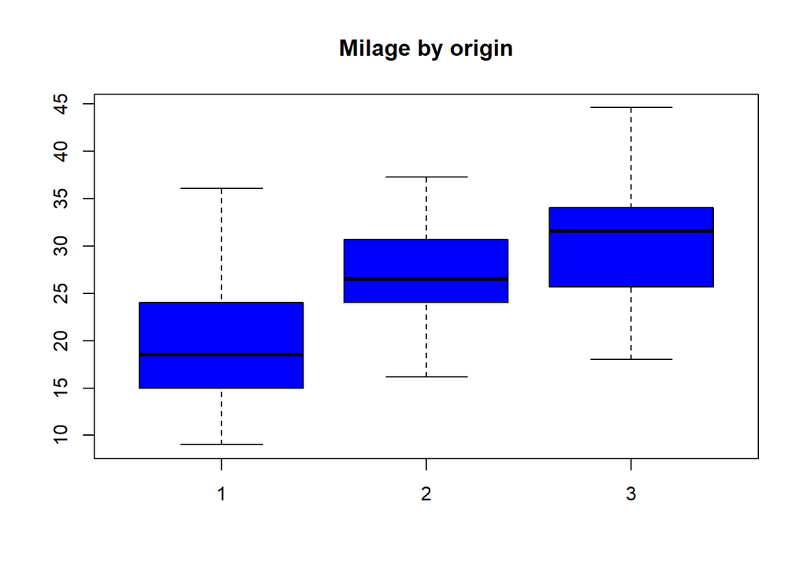

```r
boxplot(cars$mpg~cars$origin,main = "Milage by origin", outline=F, col="blue")
```

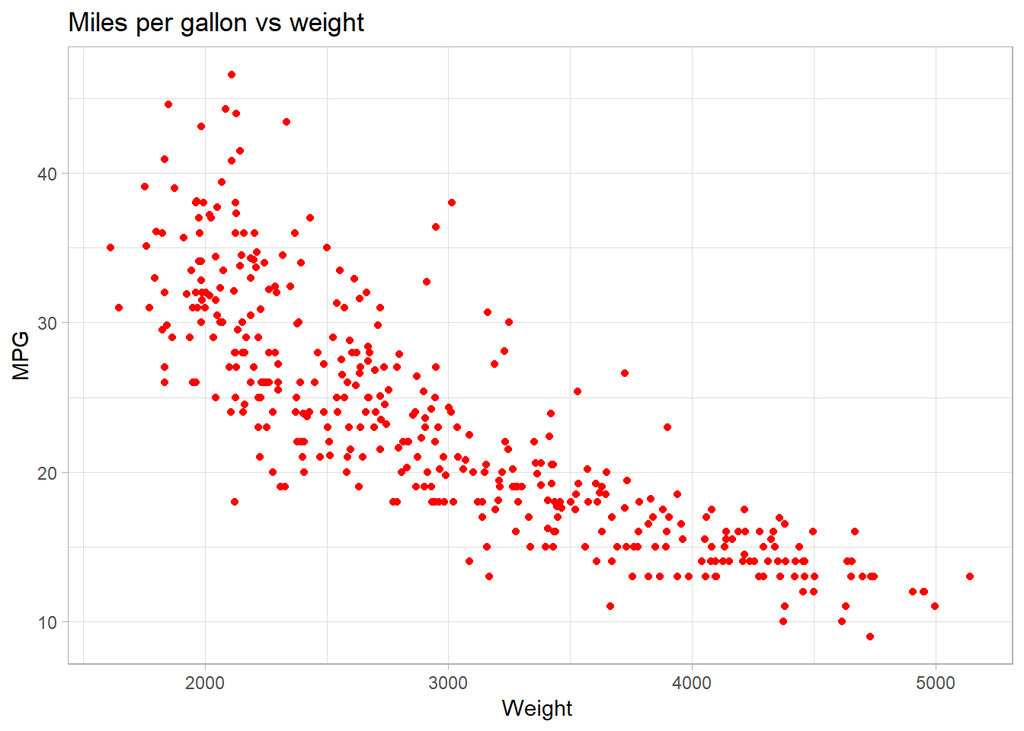

```r
ggplot(cars, aes(x = weight, y = mpg)) +
  geom_point(colour="red")+theme_light()+
  labs(x = "Weight ",y = "MPG",
    title = "Miles per gallon vs weight")
```

From the above plot, we can ascertain that indeed there exists a relationship between the weight of a car and the respective miles per gallon statistic. the trend shown by the scatterplot means that an increase in the weight of the vehicle results to a reduction in the miles per gallon consumed. This is a factor that may realistically hold, as weight increase demands more power, and as a result, more fuel is consumed.

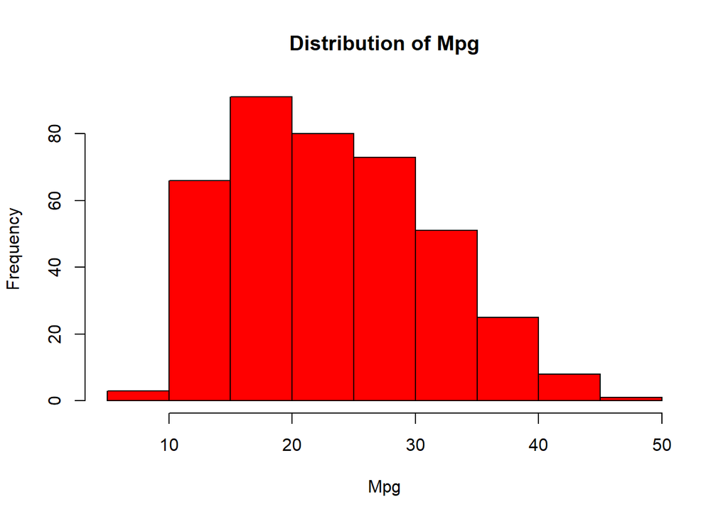

```r
hist(cars$mpg,main="Distribution of Mpg", xlab="Mpg" ,col="red")
```

From the above mileage distribution, we can see that the datapoints tend to follow a normal distribution, with the mean points being concentrated more at the center, and thus the shape of the histogram.

```r
cor(cars[,c(1,2,3,5,6,7)])
```

```
##                     mpg  cylinders displacement     weight acceleration
## mpg           1.0000000 -0.7753963   -0.8042028 -0.8317409    0.4202889
## cylinders    -0.7753963  1.0000000    0.9507214  0.8960168   -0.5054195
## displacement -0.8042028  0.9507214    1.0000000  0.9328241   -0.5436841
## weight       -0.8317409  0.8960168    0.9328241  1.0000000   -0.4174573
## acceleration  0.4202889 -0.5054195   -0.5436841 -0.4174573    1.0000000
## model year    0.5792671 -0.3487458   -0.3701642 -0.3065643    0.2881370
##              model year
## mpg           0.5792671
## cylinders    -0.3487458
## displacement -0.3701642
## weight       -0.3065643
## acceleration  0.2881370
## model year    1.0000000
```

The above correlation matrix shows that there exists a high correlation between the mpg column variable and cylinder, displacement as well as weight. this may act as a support to further research, as high correlation always implies that the respective variables hold a tight relationship.

### Problem analysis

From the summary statistics, inferences were made on whether the data had any missing observations, as well as whether the variables exhibited strong correlation. The underlying problem was to determine whether there was any existing relation between the car mile per gallon and the other variables in the dataset. To ascertain on whether there exists a relationship between the mpg variable and other related variables, we proceed and fit a regression model, which will help in analysing any predictive power that these variables have.

```r
LinearModel.1 <- lm(mpg ~ acceleration + cylinders +
  displacement + horsepower  + origin + weight, data=cars)
summary(LinearModel.1)
```

```
##
## Call:
## lm(formula = mpg ~ acceleration + cylinders + displacement +
##     horsepower + origin + weight, data = cars)
##
## Residuals:
##     Min      1Q  Median      3Q     Max
## -11.873  -1.895   0.000   1.370  15.265
##
## Coefficients:
##                   Estimate Std. Error t value Pr(>|t|)
## (Intercept)      3.729e+01  2.924e+00  12.752  < 2e-16 ***
## acceleration    -2.934e-01  1.358e-01  -2.160 0.031539 *
## cylinders       -1.423e-01  5.293e-01  -0.269 0.788184
## displacement    -4.278e-03  1.174e-02  -0.364 0.715944
## horsepower100.0 -6.783e+00  1.833e+00  -3.701 0.000256 ***
## horsepower102.0 -8.240e+00  3.960e+00  -2.081 0.038302 *
## horsepower103.0 -8.392e+00  3.935e+00  -2.133 0.033765 *
## horsepower105.0 -4.733e+00  1.933e+00  -2.448 0.014920 *
## horsepower107.0 -7.162e+00  3.970e+00  -1.804 0.072228 .
## horsepower108.0 -1.093e+01  4.046e+00  -2.702 0.007280 **
## horsepower110.0 -6.180e+00  1.842e+00  -3.354 0.000898 ***
## horsepower112.0 -8.624e+00  2.604e+00  -3.312 0.001038 **
## horsepower113.0 -5.099e+00  3.931e+00  -1.297 0.195618
## horsepower115.0 -3.523e+00  2.275e+00  -1.549 0.122540
## horsepower116.0 -5.394e+00  4.088e+00  -1.319 0.188091
## horsepower120.0 -7.994e+00  2.579e+00  -3.100 0.002122 **
## horsepower122.0 -1.077e+01  4.068e+00  -2.648 0.008528 **
## horsepower125.0 -5.713e+00  2.794e+00  -2.045 0.041730 *
## horsepower129.0 -1.033e+01  3.264e+00  -3.163 0.001720 **
## horsepower130.0 -8.983e+00  2.624e+00  -3.423 0.000706 ***
## horsepower132.0  1.575e+00  4.124e+00   0.382 0.702800
## horsepower133.0 -1.105e+01  4.043e+00  -2.733 0.006648 **
## horsepower135.0 -5.838e+00  4.117e+00  -1.418 0.157236
## horsepower137.0 -9.876e+00  4.165e+00  -2.371 0.018380 *
## horsepower138.0 -7.726e+00  4.211e+00  -1.835 0.067555 .
## horsepower139.0 -6.804e+00  3.284e+00  -2.072 0.039121 *
## horsepower140.0 -7.650e+00  2.548e+00  -3.002 0.002909 **
## horsepower142.0 -8.200e+00  4.191e+00  -1.956 0.051340 .
## horsepower145.0 -8.795e+00  2.570e+00  -3.422 0.000707 ***
```

[output cut: 61 more lines]

```
## horsepower92.00 -1.369e+00  2.111e+00  -0.649 0.517118
## horsepower93.00 -5.530e+00  3.936e+00  -1.405 0.161086
## horsepower94.00 -9.261e+00  3.932e+00  -2.355 0.019145 *
## horsepower95.00 -6.204e+00  1.816e+00  -3.416 0.000722 ***
## horsepower96.00 -3.216e+00  2.615e+00  -1.230 0.219590
## horsepower97.00 -8.331e+00  1.991e+00  -4.183 3.78e-05 ***
## horsepower98.00 -6.338e+00  2.997e+00  -2.115 0.035281 *
## origin           1.578e+00  3.961e-01   3.984 8.51e-05 ***
## weight          -2.055e-03  8.886e-04  -2.312 0.021452 *
## ---
## Signif. codes:  0 '***' 0.001 '**' 0.01 '*' 0.05 '.' 0.1 ' ' 1
##
## Residual standard error: 3.597 on 299 degrees of freedom
## Multiple R-squared:  0.8405, Adjusted R-squared:  0.7882
## F-statistic: 16.08 on 98 and 299 DF,  p-value: < 2.2e-16
```

From the fitted model, we deduce the following; The multiple and adjusted R squared values of the model are 0.8405 and 0.7882 respectively, which shows that the fitted model manages to explain and predict 84% of the model. The F statistic value too is greater than one unit, proving that indeed there is an existing relationship between the mpg value and its predictors.

From this fitted regression model, we can then fit a stepwise regression model that will help in further identifying the best mpg predictors.

```r
lm2<-step(LinearModel.1)
```

```
## Start:  AIC=1103.12
## mpg ~ acceleration + cylinders + displacement + horsepower +
##     origin + weight
##
##                Df Sum of Sq    RSS    AIC
## - cylinders     1       0.9 3869.4 1101.2
## - displacement  1       1.7 3870.2 1101.3
## <none>                      3868.5 1103.1
## - acceleration  1      60.4 3928.9 1107.3
## - weight        1      69.2 3937.6 1108.2
## - origin        1     205.4 4073.8 1121.7
## - horsepower   93    3171.8 7040.3 1155.4
##
## Step:  AIC=1101.21
## mpg ~ acceleration + displacement + horsepower + origin + weight
##
##                Df Sum of Sq    RSS    AIC
## - displacement  1       9.3 3878.7 1100.2
## <none>                      3869.4 1101.2
## - acceleration  1      61.5 3930.9 1105.5
## - weight        1      68.2 3937.7 1106.2
## - origin        1     205.9 4075.3 1119.8
## - horsepower   93    3185.7 7055.1 1154.3
##
## Step:  AIC=1100.17
## mpg ~ acceleration + horsepower + origin + weight
##
##                Df Sum of Sq    RSS    AIC
## <none>                      3878.7 1100.2
## - acceleration  1      54.9 3933.6 1103.8
## - weight        1     155.2 4033.9 1113.8
## - origin        1     289.3 4167.9 1126.8
## - horsepower   93    3183.8 7062.5 1152.7
```

```r
summary(lm2)
```

```
##
## Call:
## lm(formula = mpg ~ acceleration + horsepower + origin + weight,
##     data = cars)
##
## Residuals:
##     Min      1Q  Median      3Q     Max
## -11.641  -1.902   0.000   1.336  14.903
##
## Coefficients:
##                   Estimate Std. Error t value Pr(>|t|)
## (Intercept)      3.666e+01  2.613e+00  14.026  < 2e-16 ***
## acceleration    -2.746e-01  1.330e-01  -2.065 0.039822 *
## horsepower100.0 -7.056e+00  1.801e+00  -3.918 0.000110 ***
## horsepower102.0 -7.987e+00  3.941e+00  -2.026 0.043617 *
## horsepower103.0 -8.423e+00  3.908e+00  -2.155 0.031915 *
## horsepower105.0 -4.963e+00  1.909e+00  -2.600 0.009779 **
## horsepower107.0 -7.415e+00  3.903e+00  -1.900 0.058402 .
## horsepower108.0 -1.130e+01  3.969e+00  -2.847 0.004720 **
## horsepower110.0 -6.412e+00  1.817e+00  -3.528 0.000484 ***
## horsepower112.0 -8.639e+00  2.598e+00  -3.325 0.000994 ***
## horsepower113.0 -5.130e+00  3.922e+00  -1.308 0.191874
## horsepower115.0 -3.613e+00  2.260e+00  -1.598 0.111031
## horsepower116.0 -5.770e+00  4.024e+00  -1.434 0.152667
## horsepower120.0 -8.269e+00  2.524e+00  -3.276 0.001176 **
## horsepower122.0 -1.115e+01  3.990e+00  -2.795 0.005524 **
## horsepower125.0 -6.226e+00  2.699e+00  -2.307 0.021745 *
## horsepower129.0 -1.106e+01  3.136e+00  -3.527 0.000486 ***
## horsepower130.0 -9.560e+00  2.510e+00  -3.809 0.000169 ***
## horsepower132.0  1.225e+00  4.061e+00   0.302 0.763110
## horsepower133.0 -1.112e+01  3.975e+00  -2.797 0.005494 **
## horsepower135.0 -6.528e+00  4.030e+00  -1.620 0.106294
## horsepower137.0 -1.040e+01  4.094e+00  -2.540 0.011598 *
## horsepower138.0 -8.468e+00  4.118e+00  -2.056 0.040619 *
## horsepower139.0 -7.551e+00  3.153e+00  -2.395 0.017244 *
## horsepower140.0 -8.162e+00  2.445e+00  -3.338 0.000951 ***
## horsepower142.0 -8.921e+00  4.103e+00  -2.175 0.030441 *
## horsepower145.0 -9.436e+00  2.459e+00  -3.838 0.000151 ***
## horsepower148.0 -9.150e+00  4.289e+00  -2.133 0.033712 *
## horsepower149.0 -7.672e+00  4.163e+00  -1.843 0.066314 .
```

[output cut: 59 more lines]

```
## horsepower92.00 -1.330e+00  2.097e+00  -0.634 0.526257
## horsepower93.00 -5.632e+00  3.926e+00  -1.435 0.152468
## horsepower94.00 -9.388e+00  3.921e+00  -2.394 0.017273 *
## horsepower95.00 -6.380e+00  1.801e+00  -3.542 0.000460 ***
## horsepower96.00 -3.245e+00  2.602e+00  -1.247 0.213258
## horsepower97.00 -8.465e+00  1.980e+00  -4.276 2.56e-05 ***
## horsepower98.00 -6.381e+00  2.989e+00  -2.135 0.033608 *
## origin           1.715e+00  3.619e-01   4.738 3.33e-06 ***
## weight          -2.472e-03  7.123e-04  -3.471 0.000595 ***
## ---
## Signif. codes:  0 '***' 0.001 '**' 0.01 '*' 0.05 '.' 0.1 ' ' 1
##
## Residual standard error: 3.59 on 301 degrees of freedom
## Multiple R-squared:  0.8401, Adjusted R-squared:  0.7891
## F-statistic: 16.47 on 96 and 301 DF,  p-value: < 2.2e-16
```

### Conclusion.

This analysis involved an inferential problem on the factors influencing the mileage per gallon statistic, which is one of the most commonly used methods that people refer to when in need of a newer vehicle. Usually, based on personal preferences, individuals end up purchasing vehicles with the lowest mpg level. From our analysis, we did plot a regression model of the mile per gallon model, which upon further analysis, was deduced that the influencial factors included the acceleration, weight of the vehicle, country of origin as well as the horsepower factor. This research may be tackled on a different approach, where one may consider the other numeric variables such as acceleration or horsepower, and determine whether there is any influence from these other variables.